```python
import pandas as pd
import matplotlib.pyplot as plt
import numpy as np
import statsmodels.api as sm
from scipy import stats

%matplotlib inline
from matplotlib import font_manager, rc

font_location = "C:\Windows\Fonts\malgun.ttf"
font_name = font_manager.FontProperties(fname=font_location).get_name()
rc('font', family=font_name)
plt.rcParams['axes.unicode_minus'] = False
```

# 혈당 데이터 유의성 찾기

```python
df = pd.read_csv("국민건강보험공단_건강검진정보_2024.CSV", encoding="cp949")
```

```python
df = pd.read_csv("국민건강보험공단_건강검진정보_2024.CSV", encoding="cp949")
df['고혈당_분석용'] = (df['식전혈당(공복혈당)'] >= 126).astype(int)
df['고혈당_서비스용'] = (df['식전혈당(공복혈당)'] >= 100).astype(int)


num_cols = [
    '신장(5cm단위)', '체중(5kg단위)', '허리둘레', '수축기혈압', '이완기혈압',
    '총콜레스테롤','트리글리세라이드','HDL콜레스테롤','LDL콜레스테롤',
    '혈색소','혈청크레아티닌','혈청지오티(AST)','혈청지피티(ALT)','감마지티피'
]
cat_cols = ['성별코드','흡연상태','음주여부']

for col in num_cols:
    df[col] = df[col].fillna(df[col].median())

for col in cat_cols:
    df[col] = df[col].fillna(df[col].mode()[0])

def run_tests(target_col):
    results = []
    for col in num_cols + cat_cols:
        if col in cat_cols:
            contingency = pd.crosstab(df[col], df[target_col])
            chi2, p, _, _ = stats.chi2_contingency(contingency)
            method = "카이제곱검정"
        else:
            group0 = df[df[target_col]==0][col]
            group1 = df[df[target_col]==1][col]
            t, p = stats.ttest_ind(group0, group1, equal_var=False)
            method = "t-검정"
        results.append([col, method, p])
    return pd.DataFrame(results, columns=['변수','검정방법','p-value']).sort_values("p-value")

print(" 126 기준 (분석용)")
results_analysis = run_tests('고혈당_분석용')
print(results_analysis[results_analysis['p-value'] < 0.05])

print("\n 100 기준 (서비스용)")
results_service = run_tests('고혈당_서비스용')
print(results_service[results_service['p-value'] < 0.05])
```

```
 126 기준 (분석용)
            변수    검정방법        p-value
8     LDL콜레스테롤    t-검정   0.000000e+00
1    체중(5kg단위)    t-검정   0.000000e+00
2         허리둘레    t-검정   0.000000e+00
3        수축기혈압    t-검정   0.000000e+00
4        이완기혈압    t-검정   0.000000e+00
5       총콜레스테롤    t-검정   0.000000e+00
6     트리글리세라이드    t-검정   0.000000e+00
7     HDL콜레스테롤    t-검정   0.000000e+00
15        흡연상태  카이제곱검정   0.000000e+00
9          혈색소    t-검정   0.000000e+00
11  혈청지오티(AST)    t-검정   0.000000e+00
12  혈청지피티(ALT)    t-검정   0.000000e+00
13       감마지티피    t-검정   0.000000e+00
```

[output cut: 23 more lines]

두 가지분석 모두 유의한 변수가 비슷하다. 즉, 혈당 이상과 강하게 연관된 핵심 변수들은 두 기준에서 거의 동일하다고 볼 수 있기에 우리 웹 서비스와 연구 결과가 일관되다는 근거로 사용 가능

## 1. 고혈당 기준

126 이상: 연구용(엄격 기준)

100 이상: 서비스용(위험 신호 포함)

## 2. 결측치 처리

수치형: 중앙값 대체

범주형: 최빈값 대체

## 3. 통계 검정

범주형 변수: 카이제곱 검정

수치형 변수: t-검정

```python
features = [
    '연령대코드(5세단위)', '신장(5cm단위)', '체중(5kg단위)', '허리둘레',
    '수축기혈압','이완기혈압',
    '총콜레스테롤','트리글리세라이드','HDL콜레스테롤','LDL콜레스테롤',
    '혈색소','혈청크레아티닌','혈청지오티(AST)','혈청지피티(ALT)','감마지티피',
    '성별코드','흡연상태','음주여부'
]


df_model = pd.get_dummies(df[features + ['고혈당_분석용','고혈당_서비스용']],
                          columns=['성별코드','흡연상태','음주여부'], drop_first=True)

X1 = df_model.drop(['고혈당_분석용','고혈당_서비스용'], axis=1)
y1 = df_model['고혈당_분석용']

X1 = sm.add_constant(X1)
model1 = sm.Logit(y1, X1)
result1 = model1.fit()
print(" 로지스틱 회귀 결과 (126 기준 - 분석용)")
print(result1.summary())


y2 = df_model['고혈당_서비스용']

X2 = sm.add_constant(X1.drop('const', axis=1))
model2 = sm.Logit(y2, X2)
result2 = model2.fit()
print("\n 로지스틱 회귀 결과 (100 기준 - 서비스용)")
print(result2.summary())
```

```
Optimization terminated successfully.
         Current function value: 0.239830
         Iterations 8
 로지스틱 회귀 결과 (126 기준 - 분석용)
                           Logit Regression Results
==============================================================================
Dep. Variable:                고혈당_분석용   No. Observations:              1000000
Model:                          Logit   Df Residuals:                   999980
Method:                           MLE   Df Model:                           19
Date:                Mon, 20 Oct 2025   Pseudo R-squ.:                  0.1280
Time:                        16:59:14   Log-Likelihood:            -2.3983e+05
converged:                       True   LL-Null:                   -2.7502e+05
Covariance Type:            nonrobust   LLR p-value:                     0.000
===============================================================================
                  coef    std err          z      P>|z|      [0.025      0.975]
-------------------------------------------------------------------------------
const          -9.7003      0.157    -61.608      0.000     -10.009      -9.392
연령대코드(5세단위)     0.2230      0.002    113.582      0.000       0.219       0.227
신장(5cm단위)      -0.0062      0.001     -7.829      0.000      -0.008      -0.005
체중(5kg단위)       0.0031      0.001      4.289      0.000       0.002       0.005
허리둘레            0.0360      0.001     45.197      0.000       0.034       0.038
수축기혈압           0.0116      0.000     31.304      0.000       0.011       0.012
이완기혈압          -0.0052      0.001     -9.795      0.000      -0.006      -0.004
총콜레스테롤          0.0051      0.001      9.346      0.000       0.004       0.006
트리글리세라이드        0.0008   8.22e-05      9.831      0.000       0.001       0.001
HDL콜레스테롤       -0.0126      0.001    -18.386      0.000      -0.014      -0.011
LDL콜레스테롤       -0.0150      0.001    -25.691      0.000      -0.016      -0.014
혈색소             0.1550      0.003     45.045      0.000       0.148       0.162
혈청크레아티닌         0.0588      0.009      6.911      0.000       0.042       0.076
혈청지오티(AST)     -0.0040      0.000    -13.492      0.000      -0.005      -0.003
혈청지피티(ALT)      0.0066      0.000     30.291      0.000       0.006       0.007
감마지티피           0.0027   6.17e-05     43.136      0.000       0.003       0.003
성별코드_2          0.1048      0.015      7.164      0.000       0.076       0.134
흡연상태_2.0        0.1128      0.012      9.786      0.000       0.090       0.135
흡연상태_3.0        0.3620      0.011     31.659      0.000       0.340       0.384
음주여부_1.0        0.0066      0.009      0.714      0.475      -0.012       0.025
===============================================================================
Optimization terminated successfully.
         Current function value: 0.596012
         Iterations 6
```

[output cut: 20 more lines]

```
이완기혈압           0.0045      0.000     14.428      0.000       0.004       0.005
총콜레스테롤          0.0057      0.000     12.584      0.000       0.005       0.007
트리글리세라이드        0.0008   7.51e-05     11.040      0.000       0.001       0.001
HDL콜레스테롤       -0.0063      0.000    -13.227      0.000      -0.007      -0.005
LDL콜레스테롤       -0.0088      0.000    -18.976      0.000      -0.010      -0.008
혈색소             0.0724      0.002     36.184      0.000       0.069       0.076
혈청크레아티닌         0.0942      0.007     13.316      0.000       0.080       0.108
혈청지오티(AST)     -0.0071      0.000    -32.657      0.000      -0.008      -0.007
혈청지피티(ALT)      0.0073      0.000     42.215      0.000       0.007       0.008
감마지티피           0.0041   6.57e-05     63.001      0.000       0.004       0.004
성별코드_2          0.0661      0.008      7.960      0.000       0.050       0.082
흡연상태_2.0        0.1259      0.007     18.774      0.000       0.113       0.139
흡연상태_3.0        0.1609      0.007     23.941      0.000       0.148       0.174
음주여부_1.0        0.1156      0.005     22.051      0.000       0.105       0.126
===============================================================================
```

## 1. 변수 설정

분석에 활용한 변수: 연령, 신장, 체중, 허리둘레, 혈압, 지질, 혈액검사 지표, 성별, 흡연, 음주

범주형 처리: 성별·흡연·음주는 **더미변수(dummy variable)**로 변환 → 0/1 형태

## 2. 로지스틱 회귀 분석

126 기준 (분석용)

식전혈당 ≥ 126 → 당뇨 여부를 **종속변수(Y)**로 두고 분석

어떤 요인들이 당뇨 발생에 영향을 주는지 확인

100 기준 (서비스용)

식전혈당 ≥ 100 → 고위험군 여부를 Y로 두고 동일 변수로 분석

일반 사용자 대상 서비스용 위험 예측

## 3. 결과 활용

회귀계수와 p-value → 어떤 변수가 통계적으로 유의한지 판단

오즈비(OR) 해석 → 변수별 위험도 기여도 파악

서비스 설계 시: 유의성이 높은 변수 → 자가 테스트 질문/위험 점수 반영

```python
df['고혈당_분석용'] = (df['식전혈당(공복혈당)'] >= 126).astype(int)
df['고혈당_서비스용'] = (df['식전혈당(공복혈당)'] >= 100).astype(int)


features = [
    '연령대코드(5세단위)','신장(5cm단위)','체중(5kg단위)','허리둘레',
    '수축기혈압','이완기혈압','총콜레스테롤','트리글리세라이드',
    'HDL콜레스테롤','LDL콜레스테롤','혈색소','혈청크레아티닌',
    '혈청지오티(AST)','혈청지피티(ALT)','감마지티피',
    '성별코드','흡연상태','음주여부'
]


num_cols = [c for c in features if c not in ['성별코드','흡연상태','음주여부']]
cat_cols = ['성별코드','흡연상태','음주여부']

for col in num_cols:
    df[col] = df[col].fillna(df[col].median())
for col in cat_cols:
    df[col] = df[col].fillna(df[col].mode()[0])


X = pd.get_dummies(df[features], drop_first=True)


def run_logit(X, y):
    logit = sm.Logit(y, sm.add_constant(X))
    result = logit.fit(disp=0)
    summary_table = pd.DataFrame({
        "변수": result.params.index,
        "β (coef)": result.params.values,
        "OR (exp(β))": np.exp(result.params.values),
        "p-value": result.pvalues.values
    }).round(4)
    return summary_table


summary_126 = run_logit(X, df['고혈당_분석용'])
summary_100 = run_logit(X, df['고혈당_서비스용'])


print(" 126 기준 (분석용)")
print(summary_126)

print("\n 100 기준 (서비스용)")
print(summary_100)
```

```
 126 기준 (분석용)
             변수  β (coef)  OR (exp(β))  p-value
0         const   -9.9973       0.0000     0.00
1   연령대코드(5세단위)    0.2215       1.2480     0.00
2     신장(5cm단위)   -0.0063       0.9937     0.00
3     체중(5kg단위)    0.0030       1.0030     0.00
4          허리둘레    0.0360       1.0367     0.00
5         수축기혈압    0.0116       1.0117     0.00
6         이완기혈압   -0.0052       0.9948     0.00
7        총콜레스테롤    0.0051       1.0051     0.00
8      트리글리세라이드    0.0008       1.0008     0.00
9      HDL콜레스테롤   -0.0127       0.9874     0.00
10     LDL콜레스테롤   -0.0150       0.9852     0.00
11          혈색소    0.1559       1.1688     0.00
12      혈청크레아티닌    0.0582       1.0599     0.00
```

[output cut: 28 more lines]

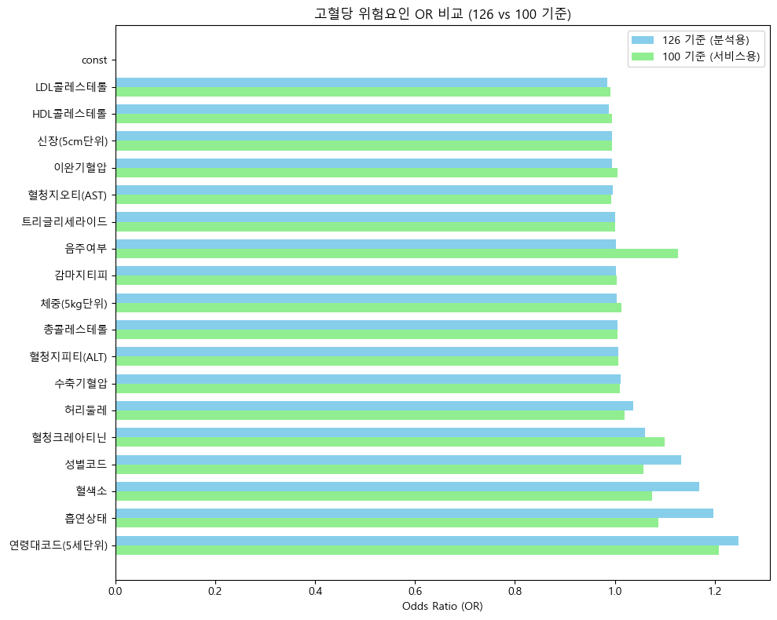

```python
merged = summary_126[['변수','OR (exp(β))']].merge(
    summary_100[['변수','OR (exp(β))']],
    on='변수',
    suffixes=('_126','_100')
)


merged = merged.sort_values('OR (exp(β))_126', ascending=False)


plt.figure(figsize=(10,8))
bar_width = 0.35
x = range(len(merged))

plt.barh([i+bar_width for i in x], merged['OR (exp(β))_126'],
         height=bar_width, label='126 기준 (분석용)', color='skyblue')
plt.barh(x, merged['OR (exp(β))_100'],
         height=bar_width, label='100 기준 (서비스용)', color='lightgreen')

plt.yticks([i+bar_width/2 for i in x], merged['변수'])
plt.xlabel("Odds Ratio (OR)")
plt.title("고혈당 위험요인 OR 비교 (126 vs 100 기준)")
plt.legend()
plt.tight_layout()
plt.show()
```

## 1. 타깃 변수 생성

126 이상 → 고혈당_분석용 (학술·의학 기준)

100 이상 → 고혈당_서비스용 (사용자 위험 신호 기준)

## 2. 설명 변수 준비

신체지표: 연령, 신장, 체중, 허리둘레

혈압/혈액/지질: 혈압, 콜레스테롤, 혈색소, 간·신장 관련 수치

생활습관: 성별, 흡연, 음주

## 3. 전처리

결측치 처리:

수치형 → 중앙값 대체

범주형 → 최빈값 대체

범주형 인코딩: 성별·흡연·음주 → 더미변수(dummy variable) 처리

## 4. 로지스틱 회귀 분석

run_logit() 함수 정의 → β(회귀계수), OR(오즈비), p-value 자동 계산

126 기준 모델과 100 기준 모델을 각각 학습

## 5. 결과 활용

p-value → 유의한 변수 선별

OR(오즈비) → 변수별 위험도 해석

자가 테스트/예상 혈당 모델 설계 근거로 사용 가능

# 인사이트 정리

126 기준: 체중 OR=1.003 → 거의 영향 없음.

100 기준: 체중 OR=1.013 → 통계적으로 의미 있음.

체중은 고혈당 위험을 민감하게 보는 사용자 기준(100)에서는 강조할 수 있음. 즉, "체중 5kg 늘면 위험이 조금씩 증가"라는 생활 친화형 메시지 가능.

```python
def calculate_risk(age_code=None, waist=None, sex=None,
                   ldl=None, tg=None, gtp=None, smoke=None,
                   hb=None, drink=None, survey_mode=False):
    """
    age_code: 5세 단위 연령코드 (예: 8=40대, 10=50대)
    waist: 허리둘레(cm)
    sex: 1=남, 2=여
    ldl: LDL 콜레스테롤
    tg: 트리글리세라이드
    gtp: 감마지티피
    smoke: 0=비흡연, 2=과거흡연, 3=현재흡연
    hb: 혈색소
    drink: 0=비음주, 1=음주
    survey_mode: True면 설문 모드(자가 응답 기반), False면 검진 데이터 기반
    """
    score = 0


    if age_code:
        if age_code >= 10: score += 2
        elif age_code >= 8: score += 1


    if waist and sex:
        if (sex == 1 and waist >= 90) or (sex == 2 and waist >= 85):
            score += 3


    if ldl:
        if ldl >= 160: score += 2
        elif ldl >= 130: score += 1
    elif survey_mode:
        score += 1


    if tg:
        if tg >= 200: score += 2
        elif tg >= 150: score += 1
    elif survey_mode:
        score += 1


    if gtp:
        if gtp >= 70: score += 2
        elif gtp >= 40: score += 1
    elif survey_mode:
        score += 1


    if smoke == 3: score += 2
    elif smoke == 2: score += 1


    if hb and sex:
        if (sex == 1 and hb > 17) or (sex == 2 and hb > 15.5):
            score += 1


    if drink == 1: score += 1


    if score >= 7:
        level = "위험"
    elif score >= 4:
        level = "경고"
    else:
        level = "주의"

    return score, level
```

1. 입력값 (사용자 특성 / 설문 응답) 나이(연령대코드): 40대(+1), 50대 이상(+2) 허리둘레: 성별 기준치 초과 시 +3 LDL, TG, 감마지티피: 수치에 따라 단계별 가점 설문 모드일 경우: 기름진 음식/단 음식/음주 습관 응답으로 간접 반영 흡연 상태: 현재흡연 +2, 과거흡연 +1 혈색소: 성별 기준치 초과 시 +1 음주 여부: +1 2. 점수 산출 로직 위험 요인에 따라 점수를 누적 (score) 검진 데이터가 없을 때는 설문 응답(survey_mode=True) 기준으로 대체 점수를 반영 3. 위험 등급 분류 7점 이상 → 위험 4~6점 → 경고 3점 이하 → 주의 활용 포인트 검진 데이터 기반: 실제 수치 입력 → 위험도 산출 설문 모드: 일반인 자가 테스트 시, 응답만으로 점수 계산 가능 결과를 점수 + 등급(주의/경고/위험) 형태로 반환 → UI/웹에서 바로 시각화 가능

```python
survey_dict = {
    "version": "1.0",
    "title": "혈당 자가 위험도 테스트",
    "sections": [
        {
            "id": "basic",
            "title": "기본 정보",
            "fields": [
                {
                    "id": "age_code",
                    "label": "연령대",
                    "type": "select",
                    "options": [
                        {"label": "20-39세", "value": 6},
                        {"label": "40-49세", "value": 8},
                        {"label": "50세 이상", "value": 10}
                    ]
                },
                {
                    "id": "sex",
                    "label": "성별",
                    "type": "radio",
                    "options": [
                        {"label": "남성", "value": 1},
                        {"label": "여성", "value": 2}
                    ]
                },
                {
                    "id": "waist",
                    "label": "허리둘레(cm)",
                    "type": "number",
                    "optional": True
                }
            ]
        },
        {
            "id": "lifestyle",
            "title": "생활습관",
            "fields": [
                {
                    "id": "smoke",
                    "label": "흡연 여부",
                    "type": "radio",
                    "options": [
                        {"label": "비흡연", "value": 0},
                        {"label": "과거 흡연", "value": 2},
                        {"label": "현재 흡연", "value": 3}
                    ]
                },
                {
                    "id": "drink",
                    "label": "음주 여부",
                    "type": "radio",
                    "options": [
                        {"label": "아니오", "value": 0},
                        {"label": "예", "value": 1}
                    ]
                }
            ]
        },
        {
            "id": "lab",
            "title": "건강검진 수치 (선택 입력)",
            "fields": [
                {"id": "ldl", "label": "LDL 콜레스테롤 (mg/dL)", "type": "number", "optional": True},
                {"id": "tg", "label": "트리글리세라이드 (mg/dL)", "type": "number", "optional": True},
                {"id": "gtp", "label": "감마지티피 (U/L)", "type": "number", "optional": True},
                {"id": "hb", "label": "혈색소 (g/dL)", "type": "number", "optional": True}
            ]
        }
    ],
    "submit": {
        "label": "위험도 계산하기",
        "action": "/api/calculate_risk"
    }
}


print(survey_dict["title"])
for sec in survey_dict["sections"]:
    print(f"- {sec['title']} ({len(sec['fields'])}개 질문)")
```

```
혈당 자가 위험도 테스트
- 기본 정보 (3개 질문)
- 생활습관 (2개 질문)
- 건강검진 수치 (선택 입력) (4개 질문)
```

1. 설문 구조 (survey_dict) 버전: "1.0" 제목: "혈당 자가 위험도 테스트" 구성 섹션: 기본 정보 연령대 (20–39, 40–49, 50+) 성별 (남성, 여성) 허리둘레(cm, 선택 입력) 생활습관 흡연 여부 (비흡연/과거흡연/현재흡연) 음주 여부 (예/아니오) 건강검진 수치 (선택 입력) LDL, TG, 감마지티피, 혈색소 → 입력해도 되고, 비워도 됨 2. 제출 버튼 라벨: “위험도 계산하기” 동작: /api/calculate_risk 호출

```python
def risk_score(row):
    score = 0


    if row['연령대코드(5세단위)'] >= 10:
        score += 2
    elif row['연령대코드(5세단위)'] >= 8:
        score += 1


    if (row['성별코드'] == 1 and row['허리둘레'] >= 90) or (row['성별코드'] == 2 and row['허리둘레'] >= 85):
        score += 3


    if row['LDL콜레스테롤'] >= 160:
        score += 2
    elif row['LDL콜레스테롤'] >= 130:
        score += 1


    if row['트리글리세라이드'] >= 200:
        score += 2
    elif row['트리글리세라이드'] >= 150:
        score += 1


    if row['감마지티피'] >= 70:
        score += 2
    elif row['감마지티피'] >= 40:
        score += 1


    if row['흡연상태'] == 3.0:
        score += 2
    elif row['흡연상태'] == 2.0:
        score += 1


    if (row['성별코드'] == 1 and row['혈색소'] > 17) or (row['성별코드'] == 2 and row['혈색소'] > 15.5):
        score += 1


    if row['음주여부'] == 1.0:
        score += 1

    return score


def risk_level(score):
    if score >= 7:
        return "위험"
    elif score >= 4:
        return "경고"
    else:
        return "주의"


df['risk_score'] = df.apply(risk_score, axis=1)
df['risk_level'] = df['risk_score'].apply(risk_level)

print(df[['연령대코드(5세단위)','허리둘레','LDL콜레스테롤','트리글리세라이드','감마지티피','흡연상태','혈색소','음주여부','risk_score','risk_level']].head(20))
```

```
    연령대코드(5세단위)  허리둘레  LDL콜레스테롤  트리글리세라이드  감마지티피  흡연상태   혈색소  음주여부  \
0            13  70.0     113.0     105.0    6.0   1.0  14.7   1.0
1            11  74.9     113.0     105.0   14.0   1.0  12.7   1.0
2            13  74.0     113.0     105.0   17.0   1.0  13.7   1.0
3            16  89.0     113.0     105.0   28.0   1.0  15.6   1.0
4            11  76.0     113.0     105.0   12.0   1.0  14.8   1.0
5            10  90.0     113.0     105.0   38.0   1.0  14.8   1.0
6            11  78.0     113.0     105.0   40.0   1.0  15.1   1.0
7             9  77.0     113.0     105.0   18.0   1.0  14.6   1.0
8            10  82.5     113.0     105.0   37.0   1.0  15.9   1.0
9            10  87.0     113.0     105.0   16.0   1.0  14.9   1.0
10           13  87.0     113.0     105.0   24.0   1.0  15.5   0.0
11            9  76.5     113.0     105.0   11.0   1.0  13.2   1.0
12            7  70.4     113.0     105.0   10.0   1.0  13.0   0.0
13            5  73.5     113.0     105.0   26.0   1.0  14.8   1.0
```

[output cut: 28 more lines]

1. 위험 점수(risk_score) 계산 기준 연령: 50세 이상 → +2 40대 → +1 허리둘레: 남 ≥90cm, 여 ≥85cm → +3 LDL 콜레스테롤: ≥160 → +2 130~159 → +1 트리글리세라이드(TG): ≥200 → +2 150~199 → +1 감마지티피(GTP): ≥70 → +2 40~69 → +1 흡연 상태: 현재흡연(3) → +2 과거흡연(2) → +1 혈색소: 남자 >17, 여자 >15.5 → +1 음주 여부: 음주(1) → +1 2. 위험 등급(risk_level) 분류 7점 이상 → 위험 4~6점 → 경고 3점 이하 → 주의

```python
from xgboost import XGBClassifier
target = "고혈당_분석용"
y = df[target]


exclude_cols = [
    "고혈당_분석용", "고혈당_서비스용", "식전혈당(공복혈당)",
    "risk_level"
]

X = df.drop(columns=exclude_cols, errors="ignore")


cat_cols = ["성별코드","흡연상태","음주여부"]
X = pd.get_dummies(X, columns=cat_cols, drop_first=True)


X = X.astype("float32")
y = y.astype("int")


X_train, X_test, y_train, y_test = train_test_split(
    X, y, test_size=0.2, random_state=42
)


neg, pos = (y_train == 0).sum(), (y_train == 1).sum()
scale = neg / pos
print(f"scale_pos_weight = {scale:.2f}")


xgb_model = XGBClassifier(
    n_estimators=300,
    max_depth=6,
    learning_rate=0.1,
    subsample=0.8,
    colsample_bytree=0.8,
    random_state=42,
    n_jobs=-1,
    scale_pos_weight=scale
)

xgb_model.fit(X_train, y_train)


print(" XGBoost (class weight 적용)")
print(classification_report(y_test, xgb_model.predict(X_test)))
```

```
scale_pos_weight = 11.76
 XGBoost (class weight 적용)
              precision    recall  f1-score   support

           0       0.97      0.69      0.81    184213
           1       0.18      0.79      0.29     15787

    accuracy                           0.70    200000
   macro avg       0.58      0.74      0.55    200000
weighted avg       0.91      0.70      0.77    200000
```

# 자가 테스트 문항/점수 체계를 데이터적으로 검증

```
 변수 중요도 (XGBoost)
             변수    중요도(gain)
25   risk_score  1125.184082
2   연령대코드(5세단위)   647.318542
29     음주여부_1.0   486.763977
17          요단백   239.532654
5          허리둘레   210.922867
26       성별코드_2   194.604980
21        감마지티피   171.865433
15     LDL콜레스테롤   161.903244
20   혈청지피티(ALT)   129.434189
19   혈청지오티(AST)   125.716179
12       총콜레스테롤   121.539520
18      혈청크레아티닌   110.883232
16          혈색소    96.447632
7         시력(우)    85.975998
6         시력(좌)    80.277061
10        수축기혈압    79.446793
13     트리글리세라이드    78.637581
28     흡연상태_3.0    67.040977
23      치아우식증유무    64.382401
11        이완기혈압    55.289452
```

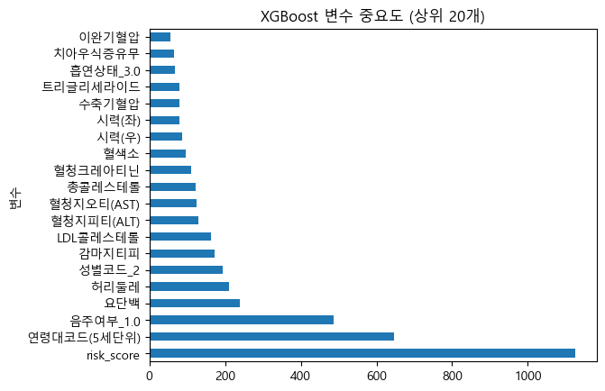

```python
importance = xgb_model.get_booster().get_score(importance_type='gain')
importance_df = pd.DataFrame({
    '변수': list(importance.keys()),
    '중요도(gain)': list(importance.values())
}).sort_values(by='중요도(gain)', ascending=False)

print(" 변수 중요도 (XGBoost)")
print(importance_df.head(20))

plt.figure(figsize=(10,6))
importance_df.head(20).plot(
    kind='barh', x='변수', y='중요도(gain)', legend=False
)
plt.title("XGBoost 변수 중요도 (상위 20개)")
plt.show()
```

## 인사이트 해석

risk_score가 압도적

risk_score가 1125로 가장 높음 → 우리가 만든 자가진단용 점수가 모델에서 가장 강력한 예측 변수로 작동했다는 의미.

즉, 웹 서비스에서 자가테스트 기능을 제공하는 게 실제 예측 성능에도 근거가 있다는 걸 보여줌.

연령·허리둘레·성별 → 고전적 위험요인

연령대, 허리둘레, 성별이 상위권.

사용자가 쉽게 이해할 수 있는 "생활 기반 위험 인자"라서 설문 항목으로 쓰기 좋음.

웹사이트 자가테스트에 포함시켜서 행동 변화 유도 메시지 줄 수 있음 ("금주·금연이 혈당 관리에 큰 영향").

임상 검사치들도 영향력 큼

LDL콜레스테롤, 감마지티피, 트리글리세라이드, 혈청지오티(AST/ALT), 혈청크레아티닌 등.

즉, 혈당만 보지 않고 대사증후군 관련 전체 프로파일이 중요하다는 걸 보여줌.

건강검진 입력을 받는다면 추가적으로 반영 가능.

의외의 요인 → 시력, 치아우식증

시력(좌/우)와 치아우식증유무도 모델이 잡아냈음.

직접적 연관은 약하지만, 전신 건강지표나 생활습관과 연관되어서 신호로 쓰였을 가능성.

인과성보다는 데이터에서 패턴을 잡은 결과로 해석.

```python
target = "고혈당_분석용"
y = df[target]


exclude_cols = ["고혈당_분석용","고혈당_서비스용","식전혈당(공복혈당)","risk_level"]
X = df.drop(columns=exclude_cols, errors="ignore")


cat_cols = ["성별코드","흡연상태","음주여부"]
X = pd.get_dummies(X, columns=cat_cols, drop_first=True)


from sklearn.model_selection import train_test_split
X_train, X_test, y_train, y_test = train_test_split(
    X, y, test_size=0.2, random_state=42
)


neg, pos = (y_train == 0).sum(), (y_train == 1).sum()
scale = neg / pos
print(f"scale_pos_weight = {scale:.2f}")



from xgboost import XGBClassifier
from sklearn.metrics import classification_report

xgb_model = XGBClassifier(
    n_estimators=300,
    max_depth=6,
    learning_rate=0.1,
    subsample=0.8,
    colsample_bytree=0.8,
    random_state=42,
    n_jobs=-1,
    scale_pos_weight=scale
)

xgb_model.fit(X_train, y_train)


print(" XGBoost (class weight 적용)")
print(classification_report(y_test, xgb_model.predict(X_test)))
```

```
scale_pos_weight = 11.76
 XGBoost (class weight 적용)
              precision    recall  f1-score   support

           0       0.97      0.69      0.81    184213
           1       0.18      0.79      0.29     15787

    accuracy                           0.70    200000
   macro avg       0.58      0.74      0.55    200000
weighted avg       0.91      0.70      0.77    200000
```

이 모델은 “고혈당 위험 예측기” 역할 → 사용자 입력(검진/설문 기반 변수)으로 고혈당 여부를 분류 평가 결과에서 재현율(recall)이 중요 → 실제 고혈당 환자를 놓치지 않는지 확인하는 지표

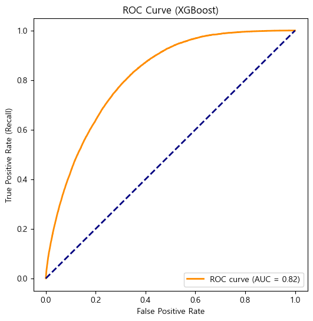

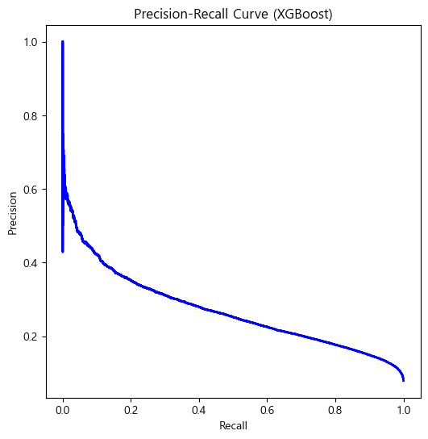

```
 최적 Threshold = 0.69
Precision = 0.26, Recall = 0.47, F1 = 0.34
```

```python
from sklearn.metrics import roc_curve, auc, precision_recall_curve


y_proba = xgb_model.predict_proba(X_test)[:, 1]


fpr, tpr, thresholds = roc_curve(y_test, y_proba)
roc_auc = auc(fpr, tpr)

plt.figure(figsize=(6,6))
plt.plot(fpr, tpr, color='darkorange', lw=2, label=f'ROC curve (AUC = {roc_auc:.2f})')
plt.plot([0, 1], [0, 1], color='navy', lw=2, linestyle='--')
plt.xlabel("False Positive Rate")
plt.ylabel("True Positive Rate (Recall)")
plt.title("ROC Curve (XGBoost)")
plt.legend(loc="lower right")
plt.show()


prec, rec, pr_thresholds = precision_recall_curve(y_test, y_proba)

plt.figure(figsize=(6,6))
plt.plot(rec, prec, color='blue', lw=2)
plt.xlabel("Recall")
plt.ylabel("Precision")
plt.title("Precision-Recall Curve (XGBoost)")
plt.show()


f1_scores = 2 * (prec * rec) / (prec + rec)
best_idx = f1_scores.argmax()
best_threshold = pr_thresholds[best_idx]

print(f" 최적 Threshold = {best_threshold:.2f}")
print(f"Precision = {prec[best_idx]:.2f}, Recall = {rec[best_idx]:.2f}, F1 = {f1_scores[best_idx]:.2f}")
```

0.5 = 무작위 수준 (쓸모 없음) 0.7~0.8 = 준수한 성능 0.8~0.9 = 좋은 성능 0.9 이상 = 매우 뛰어난 성능 0.82로 좋은 수준이 나옴.

```
scale_pos_weight = 11.76
ROC-AUC = 0.82
```

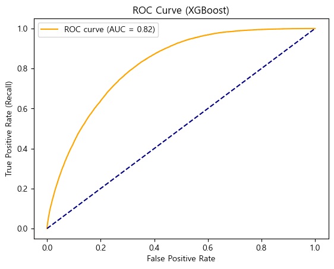

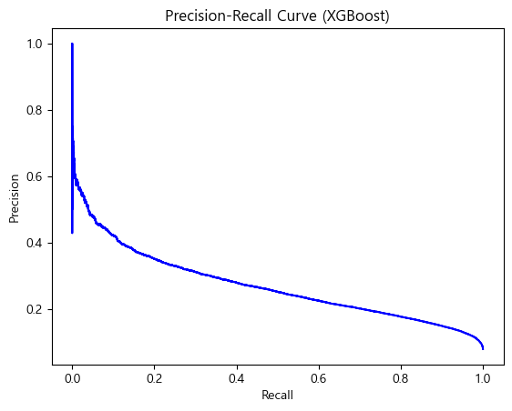

```
 최적 Threshold = 0.69
 XGBoost (Threshold 조정)
              precision    recall  f1-score   support

           0       0.95      0.88      0.92    184213
           1       0.26      0.47      0.34     15787

    accuracy                           0.85    200000
   macro avg       0.61      0.68      0.63    200000
weighted avg       0.90      0.85      0.87    200000
```

```python
target = "고혈당_분석용"
y = df[target]

exclude_cols = ["고혈당_분석용","고혈당_서비스용","식전혈당(공복혈당)","risk_level"]
X = df.drop(columns=exclude_cols, errors="ignore")


cat_cols = ["성별코드","흡연상태","음주여부"]
X = pd.get_dummies(X, columns=cat_cols, drop_first=True)


X = X.astype("float32")
y = y.astype("int")


X_train, X_test, y_train, y_test = train_test_split(
    X, y, test_size=0.2, random_state=42
)

neg, pos = (y_train == 0).sum(), (y_train == 1).sum()
scale = neg / pos
print(f"scale_pos_weight = {scale:.2f}")


xgb_model = XGBClassifier(
    n_estimators=300,
    max_depth=6,
    learning_rate=0.1,
    subsample=0.8,
    colsample_bytree=0.8,
    random_state=42,
    n_jobs=-1,
    scale_pos_weight=scale
)

xgb_model.fit(X_train, y_train)


y_pred_proba = xgb_model.predict_proba(X_test)[:,1]


auc = roc_auc_score(y_test, y_pred_proba)
print(f"ROC-AUC = {auc:.2f}")


fpr, tpr, _ = roc_curve(y_test, y_pred_proba)
plt.plot(fpr, tpr, color="orange", label=f"ROC curve (AUC = {auc:.2f})")
plt.plot([0,1],[0,1],"--",color="navy")
plt.xlabel("False Positive Rate")
plt.ylabel("True Positive Rate (Recall)")
plt.title("ROC Curve (XGBoost)")
plt.legend()
plt.show()


prec, rec, thresh = precision_recall_curve(y_test, y_pred_proba)
plt.plot(rec, prec, color="blue")
plt.xlabel("Recall")
plt.ylabel("Precision")
plt.title("Precision-Recall Curve (XGBoost)")
plt.show()


best_thresh = thresh[np.argmax(2*prec*rec/(prec+rec+1e-6))]  # F1 최대 기준
print(f" 최적 Threshold = {best_thresh:.2f}")


y_pred_custom = (y_pred_proba >= best_thresh).astype(int)

print(" XGBoost (Threshold 조정)")
print(classification_report(y_test, y_pred_custom))
```

```python
!pip install lightgbm
```

```
scale_pos_weight ≈ 11.76
[LightGBM] [Warning] Found whitespace in feature_names, replace with underlines
[LightGBM] [Info] Number of positive: 62685, number of negative: 737315
[LightGBM] [Info] Auto-choosing col-wise multi-threading, the overhead of testing was 0.070773 seconds.
You can set `force_col_wise=true` to remove the overhead.
[LightGBM] [Info] Total Bins 2799
[LightGBM] [Info] Number of data points in the train set: 800000, number of used features: 30
[LightGBM] [Info] [binary:BoostFromScore]: pavg=0.500000 -> initscore=0.000000
[LightGBM] [Info] Start training from score 0.000000
ROC-AUC = 0.82
```

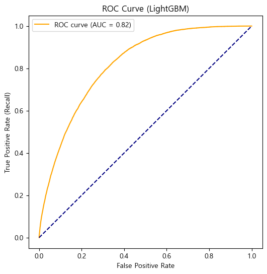

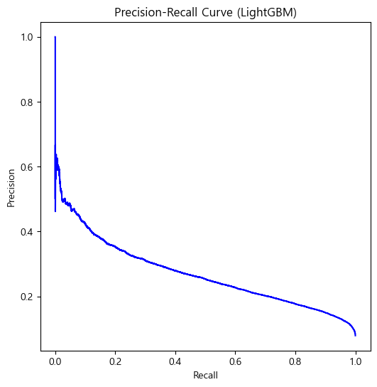

```
 최적 Threshold = 0.70
Precision = 0.26, Recall = 0.49, F1 = 0.34
 LightGBM (Threshold 조정)
              precision    recall  f1-score   support

           0       0.95      0.88      0.91    184213
           1       0.26      0.49      0.34     15787

    accuracy                           0.85    200000
   macro avg       0.60      0.68      0.63    200000
weighted avg       0.90      0.85      0.87    200000


 변수 중요도 (LightGBM 상위 20)
             변수  중요도
20   혈청지오티(AST)  751
17          혈색소  719
21   혈청지피티(ALT)  647
3   연령대코드(5세단위)  643
22        감마지티피  624
19      혈청크레아티닌  569
6          허리둘레  538
11        수축기혈압  438
12        이완기혈압  418
16     LDL콜레스테롤  411
14     트리글리세라이드  398
13       총콜레스테롤  339
18          요단백  289
5     체중(5kg단위)  283
29   risk_score  269
1       가입자일련번호  241
2          시도코드  229
4     신장(5cm단위)  202
15     HDL콜레스테롤  183
8         시력(우)  182
```

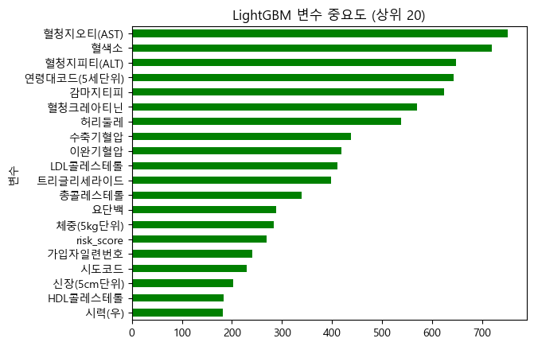

```python
target = "고혈당_분석용"
y = df[target]

exclude_cols = ["고혈당_분석용","고혈당_서비스용","식전혈당(공복혈당)","risk_level"]
X = df.drop(columns=exclude_cols, errors="ignore")


cat_cols = ["성별코드","흡연상태","음주여부"]
X = pd.get_dummies(X, columns=cat_cols, drop_first=True)


X = X.astype("float32")
y = y.astype("int")


from sklearn.model_selection import train_test_split
X_train, X_test, y_train, y_test = train_test_split(
    X, y, test_size=0.2, random_state=42
)


neg, pos = (y_train == 0).sum(), (y_train == 1).sum()
scale = neg / pos
print(f"scale_pos_weight ≈ {scale:.2f}")


from lightgbm import LGBMClassifier
from sklearn.metrics import classification_report, roc_auc_score, roc_curve, precision_recall_curve
import matplotlib.pyplot as plt
import numpy as np
import pandas as pd

lgb_model = LGBMClassifier(
    n_estimators=300,
    max_depth=-1,
    learning_rate=0.05,
    subsample=0.8,
    colsample_bytree=0.8,
    random_state=42,
    class_weight={0:1, 1:scale}
)

lgb_model.fit(X_train, y_train)


y_pred_proba = lgb_model.predict_proba(X_test)[:,1]


auc = roc_auc_score(y_test, y_pred_proba)
print(f"ROC-AUC = {auc:.2f}")


fpr, tpr, _ = roc_curve(y_test, y_pred_proba)
plt.figure(figsize=(6,6))
plt.plot(fpr, tpr, color="orange", label=f'ROC curve (AUC = {auc:.2f})')
plt.plot([0,1],[0,1],"--",color="navy")
plt.xlabel("False Positive Rate")
plt.ylabel("True Positive Rate (Recall)")
plt.title("ROC Curve (LightGBM)")
plt.legend()
plt.show()


prec, rec, thresh = precision_recall_curve(y_test, y_pred_proba)
plt.figure(figsize=(6,6))
plt.plot(rec, prec, color="blue")
plt.xlabel("Recall")
plt.ylabel("Precision")
plt.title("Precision-Recall Curve (LightGBM)")
plt.show()


f1_scores = 2 * (prec * rec) / (prec + rec + 1e-6)
best_idx = np.argmax(f1_scores)
best_thresh = thresh[best_idx]

print(f" 최적 Threshold = {best_thresh:.2f}")
print(f"Precision = {prec[best_idx]:.2f}, Recall = {rec[best_idx]:.2f}, F1 = {f1_scores[best_idx]:.2f}")


y_pred_custom = (y_pred_proba >= best_thresh).astype(int)

print(" LightGBM (Threshold 조정)")
print(classification_report(y_test, y_pred_custom))


importance_df = pd.DataFrame({
    "변수": X.columns,
    "중요도": lgb_model.feature_importances_
}).sort_values(by="중요도", ascending=False)

print("\n 변수 중요도 (LightGBM 상위 20)")
print(importance_df.head(20))

plt.figure(figsize=(10,6))
importance_df.head(20).plot(
    kind="barh", x="변수", y="중요도", legend=False, color="green"
)
plt.title("LightGBM 변수 중요도 (상위 20)")
plt.gca().invert_yaxis()
plt.show()
```

```
scale_pos_weight ≈ 11.76
[LightGBM] [Warning] Found whitespace in feature_names, replace with underlines
[LightGBM] [Info] Number of positive: 62685, number of negative: 737315
[LightGBM] [Info] Auto-choosing col-wise multi-threading, the overhead of testing was 0.075839 seconds.
You can set `force_col_wise=true` to remove the overhead.
[LightGBM] [Info] Total Bins 2799
[LightGBM] [Info] Number of data points in the train set: 800000, number of used features: 30
[LightGBM] [Info] [binary:BoostFromScore]: pavg=0.500000 -> initscore=0.000000
[LightGBM] [Info] Start training from score 0.000000
ROC-AUC = 0.82
```

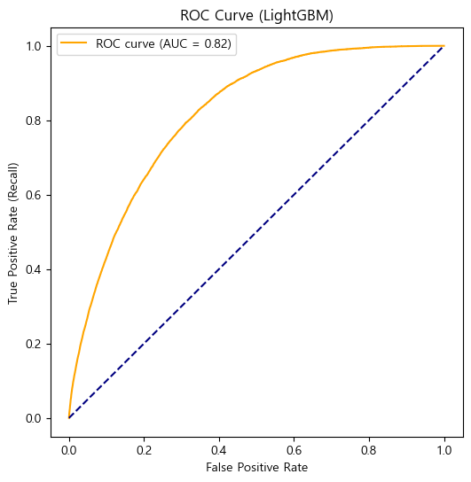

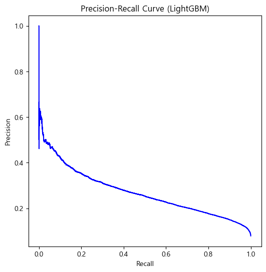

```
 최적 Threshold = 0.70
Precision = 0.26, Recall = 0.49, F1 = 0.34
 LightGBM (Threshold 조정)
              precision    recall  f1-score   support

           0       0.95      0.88      0.91    184213
           1       0.26      0.49      0.34     15787

    accuracy                           0.85    200000
   macro avg       0.60      0.68      0.63    200000
weighted avg       0.90      0.85      0.87    200000
```

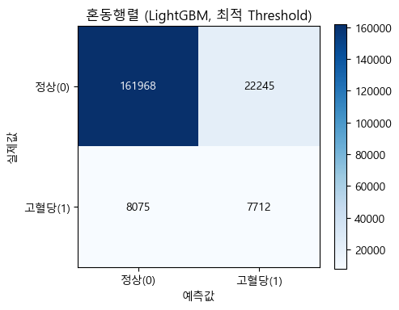

```
 변수 중요도 (LightGBM 상위 20)
             변수  중요도
20   혈청지오티(AST)  751
17          혈색소  719
21   혈청지피티(ALT)  647
3   연령대코드(5세단위)  643
22        감마지티피  624
19      혈청크레아티닌  569
6          허리둘레  538
11        수축기혈압  438
12        이완기혈압  418
16     LDL콜레스테롤  411
14     트리글리세라이드  398
13       총콜레스테롤  339
18          요단백  289
5     체중(5kg단위)  283
29   risk_score  269
1       가입자일련번호  241
2          시도코드  229
4     신장(5cm단위)  202
15     HDL콜레스테롤  183
8         시력(우)  182
```

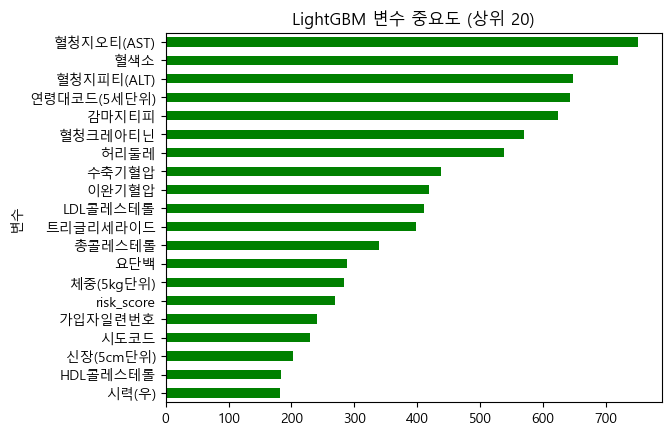

```python
target = "고혈당_분석용"
y = df[target]

exclude_cols = ["고혈당_분석용","고혈당_서비스용","식전혈당(공복혈당)","risk_level"]
X = df.drop(columns=exclude_cols, errors="ignore")


cat_cols = ["성별코드","흡연상태","음주여부"]
X = pd.get_dummies(X, columns=cat_cols, drop_first=True)


X = X.astype("float32")
y = y.astype("int")


from sklearn.model_selection import train_test_split
X_train, X_test, y_train, y_test = train_test_split(
    X, y, test_size=0.2, random_state=42
)

neg, pos = (y_train == 0).sum(), (y_train == 1).sum()
scale = neg / pos
print(f"scale_pos_weight ≈ {scale:.2f}")


from lightgbm import LGBMClassifier
from sklearn.metrics import (classification_report, roc_auc_score, roc_curve,
                             precision_recall_curve, accuracy_score,
                             precision_score, recall_score, f1_score,
                             confusion_matrix)
import matplotlib.pyplot as plt
import numpy as np
import pandas as pd

lgb_model = LGBMClassifier(
    n_estimators=300,
    max_depth=-1,
    learning_rate=0.05,
    subsample=0.8,
    colsample_bytree=0.8,
    random_state=42,
    class_weight={0:1, 1:scale}
)

lgb_model.fit(X_train, y_train)


y_pred_proba = lgb_model.predict_proba(X_test)[:,1]

auc = roc_auc_score(y_test, y_pred_proba)
print(f"ROC-AUC = {auc:.2f}")


fpr, tpr, _ = roc_curve(y_test, y_pred_proba)
plt.figure(figsize=(6,6))
plt.plot(fpr, tpr, color="orange", label=f'ROC curve (AUC = {auc:.2f})')
plt.plot([0,1],[0,1],"--",color="navy")
plt.xlabel("False Positive Rate")
plt.ylabel("True Positive Rate (Recall)")
plt.title("ROC Curve (LightGBM)")
plt.legend()
plt.show()


prec, rec, thresh = precision_recall_curve(y_test, y_pred_proba)
plt.figure(figsize=(6,6))
plt.plot(rec, prec, color="blue")
plt.xlabel("Recall")
plt.ylabel("Precision")
plt.title("Precision-Recall Curve (LightGBM)")
plt.show()


f1_scores = 2 * (prec * rec) / (prec + rec + 1e-6)
best_idx = np.argmax(f1_scores)
best_thresh = thresh[best_idx]

print(f" 최적 Threshold = {best_thresh:.2f}")
print(f"Precision = {prec[best_idx]:.2f}, Recall = {rec[best_idx]:.2f}, F1 = {f1_scores[best_idx]:.2f}")

y_pred_best = (y_pred_proba >= best_thresh).astype(int)

print(" LightGBM (Threshold 조정)")
print(classification_report(y_test, y_pred_best))


cm = confusion_matrix(y_test, y_pred_best)

plt.figure(figsize=(5,4))
plt.imshow(cm, interpolation='nearest', cmap=plt.cm.Blues)
plt.title("혼동행렬 (LightGBM, 최적 Threshold)")
plt.colorbar()


classes = ["정상(0)", "고혈당(1)"]
tick_marks = np.arange(len(classes))
plt.xticks(tick_marks, classes)
plt.yticks(tick_marks, classes)


thresh_val = cm.max() / 2
for i in range(cm.shape[0]):
    for j in range(cm.shape[1]):
        plt.text(j, i, format(cm[i, j], 'd'),
                 ha="center", va="center",
                 color="white" if cm[i, j] > thresh_val else "black")

plt.ylabel("실제값")
plt.xlabel("예측값")
plt.tight_layout()
plt.show()


importance_df = pd.DataFrame({
    "변수": X.columns,
    "중요도": lgb_model.feature_importances_
}).sort_values(by="중요도", ascending=False)

print("\n 변수 중요도 (LightGBM 상위 20)")
print(importance_df.head(20))

plt.figure(figsize=(10,6))
importance_df.head(20).plot(
    kind="barh", x="변수", y="중요도", legend=False, color="green"
)
plt.title("LightGBM 변수 중요도 (상위 20)")
plt.gca().invert_yaxis()
plt.show()
```